# Drake, Targets and Metaflow

David Neuzerling

2020-08-08

This is an implementation of a machine learning model using three different R tools:

- [`drake`, An R-focused pipeline toolkit for reproducibility and high-performance computing](https://github.com/ropensci/drake)
- [`targets`, a Make-like pipeline toolkit for Statistics and data science in R](https://github.com/wlandau/targets/)
- [`metaflow`, a human-friendly Python/R library that helps scientists and engineers build and manage real-life data science projects](https://metaflow.org/)

`drake` and `targets` are closely related, and both are “make” tools for R. `metaflow` on the other hand is closer to Airflow in its approach. All three can be used to piece together the separate components of training a machine learning model.

The model is based on the is [the *coffee* TidyTuesday data set](https://github.com/rfordatascience/tidytuesday/blob/master/data/2020/2020-07-07/readme.md). As far as machine learning models go, it’s a fairly straightforward random forest, but it does include preprocessing with the `recipes` package and hyperparameter tuning with the `tune` package. The `drake` and `targets` approaches train the model using below DAG, whereas `metaflow` implements a condensed version:

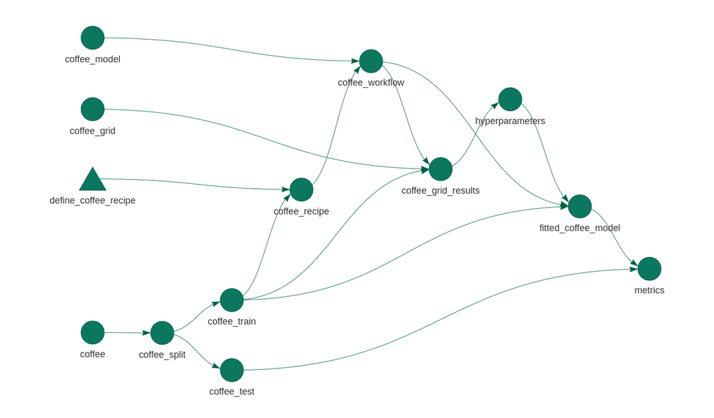

In practice, many of the helper functions in these code snippets would be kept in separate source files. I’ve included all functions here to make the comparison easier.

Thank you to [Savin Goyal](https://twitter.com/SavinGoyal) for helping me iron out the bugs in my Metaflow implementation.

## Plan comparison

### `drake`

```r
library(tidyverse)
library(tidymodels)
library(drake)

define_coffee_recipe <- function(training_data) {
  recipe(training_data) %>%
    update_role(everything(), new_role = "support") %>%
    update_role(cupper_points, new_role = "outcome") %>%
    update_role(
      variety, processing_method, country_of_origin,
      aroma, flavor, aftertaste, acidity, sweetness, altitude_mean_meters,
      new_role = "predictor"
    ) %>%
    step_string2factor(all_nominal(), -all_outcomes()) %>%
    step_knnimpute(country_of_origin,
                   impute_with = imp_vars(
                     in_country_partner, company, region, farm_name, certification_body
                   )
    ) %>%
    step_knnimpute(altitude_mean_meters,
                   impute_with = imp_vars(
                     in_country_partner, company, region, farm_name, certification_body,
                     country_of_origin
                   )
    ) %>%
    step_unknown(variety, processing_method, new_level = "Unknown") %>%
    step_other(country_of_origin, threshold = 0.01) %>%
    step_other(processing_method, threshold = 0.10) %>%
    step_other(variety, threshold = 0.10) %>%
    step_normalize(all_numeric(), -all_outcomes())
}

drake_plan(
  coffee = tidytuesdayR::tt_load(2020, week = 28)$coffee,
  coffee_split = initial_split(coffee, prop = 0.8),
  coffee_train = training(coffee_split),
  coffee_test = testing(coffee_split),
  coffee_recipe = define_coffee_recipe(coffee_train),
  coffee_model = rand_forest(trees = tune(), mtry = tune()) %>%
    set_engine("ranger") %>%
    set_mode("regression"),
  coffee_workflow = workflow() %>%
    add_recipe(coffee_recipe) %>%
    add_model(coffee_model),
  coffee_grid = expand_grid(mtry = 3:5, trees = seq(500, 1500, by = 200)),
  coffee_grid_results = coffee_workflow %>%
    tune_grid(resamples = vfold_cv(coffee_train, v = 5), grid = coffee_grid),
  hyperparameters = coffee_grid_results %>%
    select_by_pct_loss(metric = "rmse", limit = 5, trees),
  fitted_coffee_model = coffee_workflow %>%
    finalize_workflow(hyperparameters) %>%
    fit(coffee_train),
  metrics = fitted_coffee_model %>%
      predict(coffee_test) %>%
      metric_set(rmse, mae, rsq)(coffee_test$cupper_points, .pred)
)
```

### `targets`

```r
library(targets)

tar_options(packages = c("tidyverse", "tidymodels"))

define_coffee_recipe <- function(training_data) {
  recipe(training_data) %>%
    update_role(everything(), new_role = "support") %>%
    update_role(cupper_points, new_role = "outcome") %>%
    update_role(
      variety, processing_method, country_of_origin,
      aroma, flavor, aftertaste, acidity, sweetness, altitude_mean_meters,
      new_role = "predictor"
    ) %>%
    step_string2factor(all_nominal(), -all_outcomes()) %>%
    step_knnimpute(country_of_origin,
                   impute_with = imp_vars(
                     in_country_partner, company, region, farm_name, certification_body
                   )
    ) %>%
    step_knnimpute(altitude_mean_meters,
                   impute_with = imp_vars(
                     in_country_partner, company, region, farm_name, certification_body,
                     country_of_origin
                   )
    ) %>%
    step_unknown(variety, processing_method, new_level = "Unknown") %>%
    step_other(country_of_origin, threshold = 0.01) %>%
    step_other(processing_method, threshold = 0.10) %>%
    step_other(variety, threshold = 0.10) %>%
    step_normalize(all_numeric(), -all_outcomes())
}

tar_pipeline(
  tar_target(
    coffee,
    tidytuesdayR::tt_load(2020, week = 28)$coffee,
    cue = tar_cue("never")
  ),
  tar_target(coffee_split, initial_split(coffee, prop = 0.8)),
  tar_target(coffee_train, training(coffee_split)),
  tar_target(coffee_test, testing(coffee_split)),
  tar_target(coffee_recipe, define_coffee_recipe(coffee_train)),
  tar_target(
    coffee_model,
    rand_forest(
      trees = tune(),
      mtry = tune()
    ) %>% set_engine("ranger") %>% set_mode("regression")
  ),
  tar_target(
    coffee_workflow,
    workflow() %>% add_recipe(coffee_recipe) %>% add_model(coffee_model)
  ),
  tar_target(
    coffee_grid,
    expand_grid(mtry = 3:5, trees = seq(500, 1500, by = 200))
  ),
  tar_target(
    coffee_grid_results,
    coffee_workflow %>%
        tune_grid(resamples = vfold_cv(coffee_train, v = 5), grid = coffee_grid)
  ),
  tar_target(
    hyperparameters,
    select_by_pct_loss(coffee_grid_results, metric = "rmse", limit = 5, trees)
  ),
  tar_target(
    fitted_coffee_model,
    coffee_workflow %>% finalize_workflow(hyperparameters) %>% fit(coffee_train)
  ),
  tar_target(
    metrics,
    fitted_coffee_model %>%
      predict(coffee_test) %>%
      metric_set(rmse, mae, rsq)(coffee_test$cupper_points, .pred)
  )
)
```

### `metaflow`

```r
library(metaflow)

stepfunc_obtain_data <- function(self) {
  self$coffee <- tidytuesdayR::tt_load(2020, week = 28)$coffee
}
stepfunc_prepare_splits <- function(self) {
  suppressPackageStartupMessages({library(tidyverse);library(tidymodels)})
  coffee_split <- initial_split(self$coffee, prop = 0.8)
  self$coffee_train <- training(coffee_split)
  self$coffee_test <- testing(coffee_split)
}
stepfunc_define_workflow <- function(self) {
  suppressPackageStartupMessages({library(tidyverse);library(tidymodels)})
  coffee_recipe <- recipe(self$coffee_train) %>%
    update_role(everything(), new_role = "support") %>%
    update_role(cupper_points, new_role = "outcome") %>%
    update_role(
      variety, processing_method, country_of_origin,
      aroma, flavor, aftertaste, acidity, sweetness, altitude_mean_meters,
      new_role = "predictor"
    ) %>%
    step_string2factor(all_nominal(), -all_outcomes()) %>%
    step_knnimpute(country_of_origin,
                   impute_with = imp_vars(
                     in_country_partner, company, region, farm_name, certification_body
                   )
    ) %>%
    step_knnimpute(altitude_mean_meters,
                   impute_with = imp_vars(
                     in_country_partner, company, region, farm_name, certification_body,
                     country_of_origin
                   )
    ) %>%
    step_unknown(variety, processing_method, new_level = "Unknown") %>%
    step_other(country_of_origin, threshold = 0.01) %>%
    step_other(processing_method, threshold = 0.10) %>%
    step_other(variety, threshold = 0.10) %>%
    step_normalize(all_numeric(), -all_outcomes())
  coffee_model <- rand_forest(
    trees = tune(),
    mtry = tune()
  ) %>% set_engine("ranger") %>% set_mode("regression")
  self$coffee_workflow <- workflow() %>%
    add_recipe(coffee_recipe) %>%
    add_model(coffee_model)
}
stepfunc_determine_hyperparameters <- function(self) {
  suppressPackageStartupMessages({library(tidyverse);library(tidymodels)})
  coffee_grid <- expand_grid(
    mtry = 3:5,
    trees = seq(500, 1500, by = 200)
  )
  coffee_grid_results <- self$coffee_workflow %>%
    tune_grid(
      resamples = vfold_cv(self$coffee_train, v = 5),
      grid = coffee_grid
    )
  self$hyperparameters <- coffee_grid_results %>%
    select_by_pct_loss(metric = "rmse", limit = 5, trees)
}
stepfunc_fit_model <- function(self) {
  suppressPackageStartupMessages({library(tidyverse);library(tidymodels)})
  self$fitted_coffee_model <- self$coffee_workflow %>%
    finalize_workflow(self$hyperparameters) %>%
    fit(self$coffee_train)
}
stepfunc_validate_model <- function(self) {
  suppressPackageStartupMessages({library(tidyverse);library(tidymodels)})
  self$metrics <- self$fitted_coffee_model %>%
    predict(self$coffee_test) %>%
    metric_set(rmse, mae, rsq)(self$coffee_test$cupper_points, .pred)
  print(self$metrics)
}

metaflow("coffee") %>%
  step(step = "start",
       next_step = "obtain_data"
  ) %>%
  step(step = "obtain_data",
       r_function = stepfunc_obtain_data,
       next_step = "prepare_splits"
  ) %>%
  step(step = "prepare_splits",
       r_function = stepfunc_prepare_splits,
       next_step = "define_workflow"
  ) %>%
  step(step = "define_workflow",
       r_function = stepfunc_define_workflow,
       next_step = "determine_hyperparameters"
  ) %>%
  step(step = "determine_hyperparameters",
       r_function = stepfunc_determine_hyperparameters,
       next_step = "fit_model"
  ) %>%
  step(step = "fit_model",
       r_function = stepfunc_fit_model,
       next_step = "validate_model")
  ) %>%
  step(step = "validate_model",
       r_function = stepfunc_validate_model,
       next_step = "end") %>%
  step(step = "end")

run(coffee_flow)
```